# Risk Factor Analysis

## Outcome Variable

**Outcome Variable:** wast_rec90d

## Predictor Variables

**Intervention Variable:** feducyrs

**Adjustment Set:**

- arm
- W_mage
- meducyrs
- hhwealth_quart
- W_mhtcm
- W_gagebrth
- W_birthwt
- W_birthlen
- W_nrooms
- W_nchldlt5
- impfloor
- impsan
- safeh20
- delta_W_mage
- delta_meducyrs
- delta_hhwealth_quart
- delta_W_mhtcm
- delta_W_gagebrth
- delta_W_birthwt
- delta_W_birthlen
- delta_W_nrooms
- delta_W_nchldlt5
- delta_impfloor
- delta_impsan
- delta_safeh20

## Stratifying Variables

The analysis was stratified on these variable(s):

- agecat
- studyid
- country

## Data Summary

| agecat | studyid | country | feducyrs | wast_rec90d | n_cell | n |
| --- | --- | --- | --- | --- | --- | --- |
| 0-24 months | ki0047075b-MAL-ED | BANGLADESH | Low | 0 | 9 | 70 |
| 0-24 months | ki0047075b-MAL-ED | BANGLADESH | Low | 1 | 18 | 70 |
| 0-24 months | ki0047075b-MAL-ED | BANGLADESH | Medium | 0 | 10 | 70 |
| 0-24 months | ki0047075b-MAL-ED | BANGLADESH | Medium | 1 | 15 | 70 |
| 0-24 months | ki0047075b-MAL-ED | BANGLADESH | High | 0 | 6 | 70 |
| 0-24 months | ki0047075b-MAL-ED | BANGLADESH | High | 1 | 12 | 70 |
| 0-24 months | ki0047075b-MAL-ED | INDIA | Low | 0 | 16 | 103 |
| 0-24 months | ki0047075b-MAL-ED | INDIA | Low | 1 | 31 | 103 |
| 0-24 months | ki0047075b-MAL-ED | INDIA | Medium | 0 | 15 | 103 |
| 0-24 months | ki0047075b-MAL-ED | INDIA | Medium | 1 | 13 | 103 |
| 0-24 months | ki0047075b-MAL-ED | INDIA | High | 0 | 7 | 103 |
| 0-24 months | ki0047075b-MAL-ED | INDIA | High | 1 | 21 | 103 |
| 0-24 months | ki0047075b-MAL-ED | NEPAL | Low | 0 | 2 | 34 |
| 0-24 months | ki0047075b-MAL-ED | NEPAL | Low | 1 | 9 | 34 |
| 0-24 months | ki0047075b-MAL-ED | NEPAL | Medium | 0 | 4 | 34 |
| 0-24 months | ki0047075b-MAL-ED | NEPAL | Medium | 1 | 8 | 34 |
| 0-24 months | ki0047075b-MAL-ED | NEPAL | High | 0 | 2 | 34 |
| 0-24 months | ki0047075b-MAL-ED | NEPAL | High | 1 | 9 | 34 |
| 0-24 months | ki0047075b-MAL-ED | PERU | Low | 0 | 1 | 25 |
| 0-24 months | ki0047075b-MAL-ED | PERU | Low | 1 | 3 | 25 |
| 0-24 months | ki0047075b-MAL-ED | PERU | Medium | 0 | 1 | 25 |
| 0-24 months | ki0047075b-MAL-ED | PERU | Medium | 1 | 10 | 25 |
| 0-24 months | ki0047075b-MAL-ED | PERU | High | 0 | 2 | 25 |
| 0-24 months | ki0047075b-MAL-ED | PERU | High | 1 | 8 | 25 |
| 0-24 months | ki0047075b-MAL-ED | SOUTH AFRICA | Low | 0 | 3 | 28 |
| 0-24 months | ki0047075b-MAL-ED | SOUTH AFRICA | Low | 1 | 8 | 28 |
| 0-24 months | ki0047075b-MAL-ED | SOUTH AFRICA | Medium | 0 | 1 | 28 |
| 0-24 months | ki0047075b-MAL-ED | SOUTH AFRICA | Medium | 1 | 7 | 28 |
| 0-24 months | ki0047075b-MAL-ED | SOUTH AFRICA | High | 0 | 2 | 28 |
| 0-24 months | ki0047075b-MAL-ED | SOUTH AFRICA | High | 1 | 7 | 28 |

[output cut: 330 more lines]

The following strata were considered:

- agecat: 0-24 months, studyid: ki0047075b-MAL-ED, country: BANGLADESH
- agecat: 0-24 months, studyid: ki0047075b-MAL-ED, country: INDIA
- agecat: 0-24 months, studyid: ki0047075b-MAL-ED, country: NEPAL
- agecat: 0-24 months, studyid: ki0047075b-MAL-ED, country: PERU
- agecat: 0-24 months, studyid: ki0047075b-MAL-ED, country: SOUTH AFRICA
- agecat: 0-24 months, studyid: ki0047075b-MAL-ED, country: TANZANIA, UNITED REPUBLIC OF
- agecat: 0-24 months, studyid: ki1000304b-SAS-CompFeed, country: INDIA
- agecat: 0-24 months, studyid: ki1000304b-SAS-FoodSuppl, country: INDIA
- agecat: 0-24 months, studyid: ki1017093b-PROVIDE, country: BANGLADESH
- agecat: 0-24 months, studyid: ki1017093c-NIH-Crypto, country: BANGLADESH
- agecat: 0-24 months, studyid: ki1066203-TanzaniaChild2, country: TANZANIA, UNITED REPUBLIC OF
- agecat: 0-24 months, studyid: ki1113344-GMS-Nepal, country: NEPAL
- agecat: 0-24 months, studyid: ki1119695-PROBIT, country: BELARUS
- agecat: 0-24 months, studyid: ki1126311-ZVITAMBO, country: ZIMBABWE
- agecat: 0-24 months, studyid: ki1135781-COHORTS, country: GUATEMALA
- agecat: 0-24 months, studyid: ki1135781-COHORTS, country: INDIA
- agecat: 0-24 months, studyid: ki1135781-COHORTS, country: PHILIPPINES
- agecat: 0-24 months, studyid: ki1148112-LCNI-5, country: MALAWI
- agecat: 0-24 months, studyid: kiGH5241-JiVitA-3, country: BANGLADESH
- agecat: 0-24 months, studyid: kiGH5241-JiVitA-4, country: BANGLADESH
- agecat: 0-6 months, studyid: ki0047075b-MAL-ED, country: BANGLADESH
- agecat: 0-6 months, studyid: ki0047075b-MAL-ED, country: INDIA
- agecat: 0-6 months, studyid: ki0047075b-MAL-ED, country: NEPAL
- agecat: 0-6 months, studyid: ki0047075b-MAL-ED, country: PERU
- agecat: 0-6 months, studyid: ki0047075b-MAL-ED, country: SOUTH AFRICA
- agecat: 0-6 months, studyid: ki0047075b-MAL-ED, country: TANZANIA, UNITED REPUBLIC OF
- agecat: 0-6 months, studyid: ki1000304b-SAS-CompFeed, country: INDIA
- agecat: 0-6 months, studyid: ki1000304b-SAS-FoodSuppl, country: INDIA
- agecat: 0-6 months, studyid: ki1017093b-PROVIDE, country: BANGLADESH
- agecat: 0-6 months, studyid: ki1017093c-NIH-Crypto, country: BANGLADESH
- agecat: 0-6 months, studyid: ki1066203-TanzaniaChild2, country: TANZANIA, UNITED REPUBLIC OF
- agecat: 0-6 months, studyid: ki1113344-GMS-Nepal, country: NEPAL
- agecat: 0-6 months, studyid: ki1119695-PROBIT, country: BELARUS
- agecat: 0-6 months, studyid: ki1126311-ZVITAMBO, country: ZIMBABWE
- agecat: 0-6 months, studyid: ki1135781-COHORTS, country: GUATEMALA
- agecat: 0-6 months, studyid: ki1135781-COHORTS, country: INDIA
- agecat: 0-6 months, studyid: ki1135781-COHORTS, country: PHILIPPINES
- agecat: 0-6 months, studyid: ki1148112-LCNI-5, country: MALAWI
- agecat: 0-6 months, studyid: kiGH5241-JiVitA-3, country: BANGLADESH
- agecat: 0-6 months, studyid: kiGH5241-JiVitA-4, country: BANGLADESH
- agecat: 6-24 months, studyid: ki0047075b-MAL-ED, country: BANGLADESH
- agecat: 6-24 months, studyid: ki0047075b-MAL-ED, country: INDIA
- agecat: 6-24 months, studyid: ki0047075b-MAL-ED, country: NEPAL
- agecat: 6-24 months, studyid: ki0047075b-MAL-ED, country: PERU
- agecat: 6-24 months, studyid: ki0047075b-MAL-ED, country: SOUTH AFRICA
- agecat: 6-24 months, studyid: ki0047075b-MAL-ED, country: TANZANIA, UNITED REPUBLIC OF
- agecat: 6-24 months, studyid: ki1000304b-SAS-CompFeed, country: INDIA
- agecat: 6-24 months, studyid: ki1000304b-SAS-FoodSuppl, country: INDIA
- agecat: 6-24 months, studyid: ki1017093b-PROVIDE, country: BANGLADESH
- agecat: 6-24 months, studyid: ki1017093c-NIH-Crypto, country: BANGLADESH
- agecat: 6-24 months, studyid: ki1066203-TanzaniaChild2, country: TANZANIA, UNITED REPUBLIC OF
- agecat: 6-24 months, studyid: ki1113344-GMS-Nepal, country: NEPAL
- agecat: 6-24 months, studyid: ki1119695-PROBIT, country: BELARUS
- agecat: 6-24 months, studyid: ki1126311-ZVITAMBO, country: ZIMBABWE
- agecat: 6-24 months, studyid: ki1135781-COHORTS, country: GUATEMALA
- agecat: 6-24 months, studyid: ki1135781-COHORTS, country: INDIA
- agecat: 6-24 months, studyid: ki1135781-COHORTS, country: PHILIPPINES
- agecat: 6-24 months, studyid: ki1148112-LCNI-5, country: MALAWI
- agecat: 6-24 months, studyid: kiGH5241-JiVitA-3, country: BANGLADESH
- agecat: 6-24 months, studyid: kiGH5241-JiVitA-4, country: BANGLADESH

### Dropped Strata

Some strata were dropped due to rare outcomes:

- agecat: 0-24 months, studyid: ki0047075b-MAL-ED, country: NEPAL
- agecat: 0-24 months, studyid: ki0047075b-MAL-ED, country: PERU
- agecat: 0-24 months, studyid: ki0047075b-MAL-ED, country: SOUTH AFRICA
- agecat: 0-24 months, studyid: ki0047075b-MAL-ED, country: TANZANIA, UNITED REPUBLIC OF
- agecat: 0-24 months, studyid: ki1000304b-SAS-FoodSuppl, country: INDIA
- agecat: 0-24 months, studyid: ki1148112-LCNI-5, country: MALAWI
- agecat: 0-6 months, studyid: ki0047075b-MAL-ED, country: BANGLADESH
- agecat: 0-6 months, studyid: ki0047075b-MAL-ED, country: INDIA
- agecat: 0-6 months, studyid: ki0047075b-MAL-ED, country: NEPAL
- agecat: 0-6 months, studyid: ki0047075b-MAL-ED, country: PERU
- agecat: 0-6 months, studyid: ki0047075b-MAL-ED, country: SOUTH AFRICA
- agecat: 0-6 months, studyid: ki0047075b-MAL-ED, country: TANZANIA, UNITED REPUBLIC OF
- agecat: 0-6 months, studyid: ki1000304b-SAS-FoodSuppl, country: INDIA
- agecat: 0-6 months, studyid: ki1017093c-NIH-Crypto, country: BANGLADESH
- agecat: 0-6 months, studyid: ki1148112-LCNI-5, country: MALAWI
- agecat: 6-24 months, studyid: ki0047075b-MAL-ED, country: BANGLADESH
- agecat: 6-24 months, studyid: ki0047075b-MAL-ED, country: NEPAL
- agecat: 6-24 months, studyid: ki0047075b-MAL-ED, country: PERU
- agecat: 6-24 months, studyid: ki0047075b-MAL-ED, country: SOUTH AFRICA
- agecat: 6-24 months, studyid: ki0047075b-MAL-ED, country: TANZANIA, UNITED REPUBLIC OF
- agecat: 6-24 months, studyid: ki1000304b-SAS-FoodSuppl, country: INDIA
- agecat: 6-24 months, studyid: ki1017093c-NIH-Crypto, country: BANGLADESH
- agecat: 6-24 months, studyid: ki1126311-ZVITAMBO, country: ZIMBABWE
- agecat: 6-24 months, studyid: ki1135781-COHORTS, country: GUATEMALA
- agecat: 6-24 months, studyid: ki1135781-COHORTS, country: INDIA
- agecat: 6-24 months, studyid: ki1148112-LCNI-5, country: MALAWI
- agecat: 6-24 months, studyid: kiGH5241-JiVitA-3, country: BANGLADESH

## Methods Detail

We’re interested in the causal parameters $E[Y_a]$ for all values of $a \in \mathcal{A}$. These parameters represent the mean outcome if, possibly contrary to fact, we intervened to set all units to have $A=a$. Under the randomization and positivity assumptions, these are identified by the statistical parameters $\psi_a=E_W[E_{Y|A,W}(Y|A=a,W)]$. In addition, we’re interested in the mean of $Y$, $E[Y]$ under no intervention (the observed mean). We will estimate these parameters by using SuperLearner to fit the relevant likelihood factors – $E_{Y|A,W}(Y|A=a,W)$ and $p(A=a|W)$, and then updating our likelihood fit using a joint TMLE.

For unadjusted analyses ($W=\{\}$), initial likelihoods were estimated using Lrnr_glm to estimate the simple $E(Y|A)$ and Lrnr_mean to estimate $p(A)$. For adjusted analyses, a small library containing Lrnr_glmnet, Lrnr_xgboost, and Lrnr_mean was used.

Having estimated these parameters, we will then use the delta method to estimate relative risks and attributable risks relative to a prespecified baseline level of $A$.

# Results Detail

## Results Plots

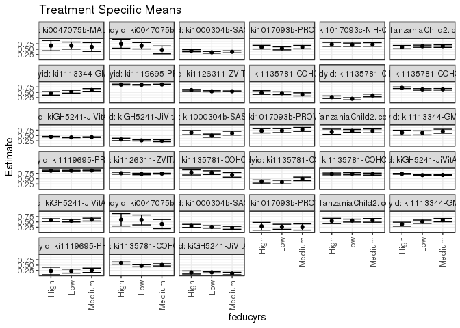

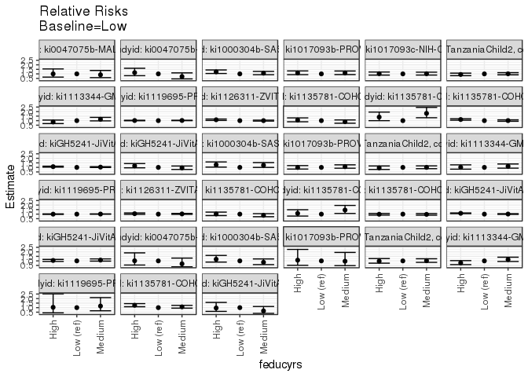

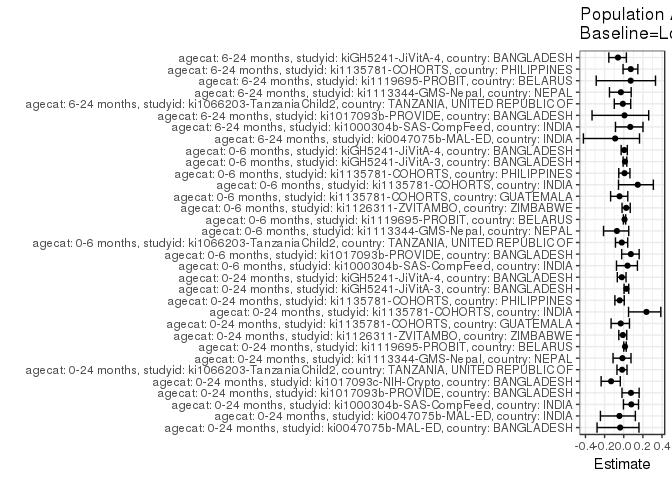

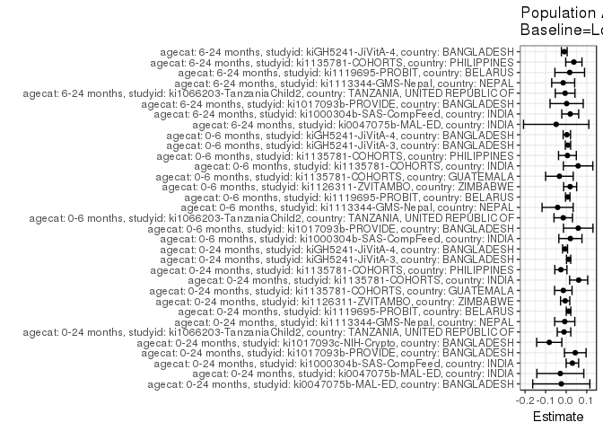

## Results Table

### Parameter: TSM

| agecat | studyid | country | intervention_level | baseline_level | estimate | ci_lower | ci_upper |
| --- | --- | --- | --- | --- | --- | --- | --- |
| 0-24 months | ki0047075b-MAL-ED | BANGLADESH | Low | NA | 0.6666667 | 0.5025048 | 0.8308285 |
| 0-24 months | ki0047075b-MAL-ED | BANGLADESH | Medium | NA | 0.6000000 | 0.3938977 | 0.8061023 |
| 0-24 months | ki0047075b-MAL-ED | BANGLADESH | High | NA | 0.6666667 | 0.4269601 | 0.9063732 |
| 0-24 months | ki0047075b-MAL-ED | INDIA | Low | NA | 0.6595745 | 0.5113855 | 0.8077634 |
| 0-24 months | ki0047075b-MAL-ED | INDIA | Medium | NA | 0.4642857 | 0.2805212 | 0.6480502 |
| 0-24 months | ki0047075b-MAL-ED | INDIA | High | NA | 0.7500000 | 0.5458782 | 0.9541218 |
| 0-24 months | ki1000304b-SAS-CompFeed | INDIA | Low | NA | 0.3520259 | 0.3087225 | 0.3953293 |
| 0-24 months | ki1000304b-SAS-CompFeed | INDIA | Medium | NA | 0.3786811 | 0.3306962 | 0.4266660 |
| 0-24 months | ki1000304b-SAS-CompFeed | INDIA | High | NA | 0.4305614 | 0.3820362 | 0.4790865 |
| 0-24 months | ki1017093b-PROVIDE | BANGLADESH | Low | NA | 0.5389343 | 0.4682403 | 0.6096282 |
| 0-24 months | ki1017093b-PROVIDE | BANGLADESH | Medium | NA | 0.5951567 | 0.5163043 | 0.6740092 |
| 0-24 months | ki1017093b-PROVIDE | BANGLADESH | High | NA | 0.5940995 | 0.5098632 | 0.6783357 |
| 0-24 months | ki1017093c-NIH-Crypto | BANGLADESH | Low | NA | 0.7060313 | 0.6291264 | 0.7829362 |
| 0-24 months | ki1017093c-NIH-Crypto | BANGLADESH | Medium | NA | 0.7171613 | 0.6326398 | 0.8016829 |
| 0-24 months | ki1017093c-NIH-Crypto | BANGLADESH | High | NA | 0.7219313 | 0.6298968 | 0.8139659 |
| 0-24 months | ki1066203-TanzaniaChild2 | TANZANIA, UNITED REPUBLIC OF | Low | NA | 0.6378717 | 0.5888135 | 0.6869299 |
| 0-24 months | ki1066203-TanzaniaChild2 | TANZANIA, UNITED REPUBLIC OF | Medium | NA | 0.6425274 | 0.5852163 | 0.6998385 |
| 0-24 months | ki1066203-TanzaniaChild2 | TANZANIA, UNITED REPUBLIC OF | High | NA | 0.5947765 | 0.5189163 | 0.6706367 |
| 0-24 months | ki1113344-GMS-Nepal | NEPAL | Low | NA | 0.5294329 | 0.4608404 | 0.5980254 |
| 0-24 months | ki1113344-GMS-Nepal | NEPAL | Medium | NA | 0.6091368 | 0.5451219 | 0.6731516 |
| 0-24 months | ki1113344-GMS-Nepal | NEPAL | High | NA | 0.4491278 | 0.3659293 | 0.5323263 |
| 0-24 months | ki1119695-PROBIT | BELARUS | Low | NA | 0.8485110 | 0.8336589 | 0.8633631 |
| 0-24 months | ki1119695-PROBIT | BELARUS | Medium | NA | 0.8640653 | 0.8503128 | 0.8778179 |
| 0-24 months | ki1119695-PROBIT | BELARUS | High | NA | 0.8594003 | 0.8392874 | 0.8795131 |
| 0-24 months | ki1126311-ZVITAMBO | ZIMBABWE | Low | NA | 0.5485815 | 0.5224428 | 0.5747202 |
| 0-24 months | ki1126311-ZVITAMBO | ZIMBABWE | Medium | NA | 0.5488903 | 0.5309569 | 0.5668236 |
| 0-24 months | ki1126311-ZVITAMBO | ZIMBABWE | High | NA | 0.6009614 | 0.5663049 | 0.6356179 |
| 0-24 months | ki1135781-COHORTS | GUATEMALA | Low | NA | 0.4581739 | 0.3918032 | 0.5245446 |
| 0-24 months | ki1135781-COHORTS | GUATEMALA | Medium | NA | 0.4026700 | 0.3288150 | 0.4765249 |
| 0-24 months | ki1135781-COHORTS | GUATEMALA | High | NA | 0.4888347 | 0.4021715 | 0.5754979 |

[output cut: 69 more lines]

### Parameter: E(Y)

| agecat | studyid | country | intervention_level | baseline_level | estimate | ci_lower | ci_upper |
| --- | --- | --- | --- | --- | --- | --- | --- |
| 0-24 months | ki0047075b-MAL-ED | BANGLADESH | NA | NA | 0.6428571 | 0.5282860 | 0.7574282 |
| 0-24 months | ki0047075b-MAL-ED | INDIA | NA | NA | 0.6310680 | 0.5256054 | 0.7365305 |
| 0-24 months | ki1000304b-SAS-CompFeed | INDIA | NA | NA | 0.3822441 | 0.3470990 | 0.4173892 |
| 0-24 months | ki1017093b-PROVIDE | BANGLADESH | NA | NA | 0.5830619 | 0.5262762 | 0.6398476 |
| 0-24 months | ki1017093c-NIH-Crypto | BANGLADESH | NA | NA | 0.6237942 | 0.5698223 | 0.6777662 |
| 0-24 months | ki1066203-TanzaniaChild2 | TANZANIA, UNITED REPUBLIC OF | NA | NA | 0.6272855 | 0.5895954 | 0.6649756 |
| 0-24 months | ki1113344-GMS-Nepal | NEPAL | NA | NA | 0.5223614 | 0.4773383 | 0.5673845 |
| 0-24 months | ki1119695-PROBIT | BELARUS | NA | NA | 0.8600563 | 0.8497279 | 0.8703846 |
| 0-24 months | ki1126311-ZVITAMBO | ZIMBABWE | NA | NA | 0.5436300 | 0.5268423 | 0.5604178 |
| 0-24 months | ki1135781-COHORTS | GUATEMALA | NA | NA | 0.4441341 | 0.3908676 | 0.4974005 |
| 0-24 months | ki1135781-COHORTS | INDIA | NA | NA | 0.2560297 | 0.2186976 | 0.2933617 |
| 0-24 months | ki1135781-COHORTS | PHILIPPINES | NA | NA | 0.6092757 | 0.5839352 | 0.6346162 |
| 0-24 months | kiGH5241-JiVitA-3 | BANGLADESH | NA | NA | 0.4234308 | 0.4120875 | 0.4347742 |
| 0-24 months | kiGH5241-JiVitA-4 | BANGLADESH | NA | NA | 0.2635315 | 0.2373454 | 0.2897176 |
| 0-6 months | ki1000304b-SAS-CompFeed | INDIA | NA | NA | 0.5147059 | 0.4610948 | 0.5683169 |
| 0-6 months | ki1017093b-PROVIDE | BANGLADESH | NA | NA | 0.7880435 | 0.7295878 | 0.8464992 |
| 0-6 months | ki1066203-TanzaniaChild2 | TANZANIA, UNITED REPUBLIC OF | NA | NA | 0.7029412 | 0.6536517 | 0.7522307 |
| 0-6 months | ki1113344-GMS-Nepal | NEPAL | NA | NA | 0.5833333 | 0.5108676 | 0.6557991 |
| 0-6 months | ki1119695-PROBIT | BELARUS | NA | NA | 0.8851500 | 0.8753163 | 0.8949836 |
| 0-6 months | ki1126311-ZVITAMBO | ZIMBABWE | NA | NA | 0.7416564 | 0.7242528 | 0.7590599 |
| 0-6 months | ki1135781-COHORTS | GUATEMALA | NA | NA | 0.7512438 | 0.6914852 | 0.8110023 |
| 0-6 months | ki1135781-COHORTS | INDIA | NA | NA | 0.3954155 | 0.3440450 | 0.4467860 |
| 0-6 months | ki1135781-COHORTS | PHILIPPINES | NA | NA | 0.7402032 | 0.7074271 | 0.7729793 |
| 0-6 months | kiGH5241-JiVitA-3 | BANGLADESH | NA | NA | 0.6768386 | 0.6632567 | 0.6904206 |
| 0-6 months | kiGH5241-JiVitA-4 | BANGLADESH | NA | NA | 0.5606557 | 0.5048650 | 0.6164465 |
| 6-24 months | ki0047075b-MAL-ED | INDIA | NA | NA | 0.5438596 | 0.3951895 | 0.6925298 |
| 6-24 months | ki1000304b-SAS-CompFeed | INDIA | NA | NA | 0.2866242 | 0.2446853 | 0.3285631 |
| 6-24 months | ki1017093b-PROVIDE | BANGLADESH | NA | NA | 0.2764228 | 0.1950773 | 0.3577682 |
| 6-24 months | ki1066203-TanzaniaChild2 | TANZANIA, UNITED REPUBLIC OF | NA | NA | 0.5579515 | 0.5056058 | 0.6102972 |
| 6-24 months | ki1113344-GMS-Nepal | NEPAL | NA | NA | 0.4934037 | 0.4386266 | 0.5481808 |
| 6-24 months | ki1119695-PROBIT | BELARUS | NA | NA | 0.2363636 | 0.1715730 | 0.3011543 |
| 6-24 months | ki1135781-COHORTS | PHILIPPINES | NA | NA | 0.5073446 | 0.4725123 | 0.5421770 |
| 6-24 months | kiGH5241-JiVitA-4 | BANGLADESH | NA | NA | 0.1532847 | 0.1289083 | 0.1776610 |

### Parameter: RR

| agecat | studyid | country | intervention_level | baseline_level | estimate | ci_lower | ci_upper |
| --- | --- | --- | --- | --- | --- | --- | --- |
| 0-24 months | ki0047075b-MAL-ED | BANGLADESH | Low | Low | 1.0000000 | 1.0000000 | 1.000000 |
| 0-24 months | ki0047075b-MAL-ED | BANGLADESH | Medium | Low | 0.9000000 | 0.5886339 | 1.376067 |
| 0-24 months | ki0047075b-MAL-ED | BANGLADESH | High | Low | 1.0000000 | 0.6465372 | 1.546701 |
| 0-24 months | ki0047075b-MAL-ED | INDIA | Low | Low | 1.0000000 | 1.0000000 | 1.000000 |
| 0-24 months | ki0047075b-MAL-ED | INDIA | Medium | Low | 0.7039171 | 0.4465685 | 1.109571 |
| 0-24 months | ki0047075b-MAL-ED | INDIA | High | Low | 1.1370968 | 0.7989755 | 1.618309 |
| 0-24 months | ki1000304b-SAS-CompFeed | INDIA | Low | Low | 1.0000000 | 1.0000000 | 1.000000 |
| 0-24 months | ki1000304b-SAS-CompFeed | INDIA | Medium | Low | 1.0757195 | 0.9085530 | 1.273643 |
| 0-24 months | ki1000304b-SAS-CompFeed | INDIA | High | Low | 1.2230957 | 1.0432695 | 1.433918 |
| 0-24 months | ki1017093b-PROVIDE | BANGLADESH | Low | Low | 1.0000000 | 1.0000000 | 1.000000 |
| 0-24 months | ki1017093b-PROVIDE | BANGLADESH | Medium | Low | 1.1043216 | 0.9253470 | 1.317912 |
| 0-24 months | ki1017093b-PROVIDE | BANGLADESH | High | Low | 1.1023598 | 0.9150171 | 1.328059 |
| 0-24 months | ki1017093c-NIH-Crypto | BANGLADESH | Low | Low | 1.0000000 | 1.0000000 | 1.000000 |
| 0-24 months | ki1017093c-NIH-Crypto | BANGLADESH | Medium | Low | 1.0157642 | 0.8682766 | 1.188305 |
| 0-24 months | ki1017093c-NIH-Crypto | BANGLADESH | High | Low | 1.0225203 | 0.8681407 | 1.204353 |
| 0-24 months | ki1066203-TanzaniaChild2 | TANZANIA, UNITED REPUBLIC OF | Low | Low | 1.0000000 | 1.0000000 | 1.000000 |
| 0-24 months | ki1066203-TanzaniaChild2 | TANZANIA, UNITED REPUBLIC OF | Medium | Low | 1.0072988 | 0.8960666 | 1.132339 |
| 0-24 months | ki1066203-TanzaniaChild2 | TANZANIA, UNITED REPUBLIC OF | High | Low | 0.9324391 | 0.8039439 | 1.081472 |
| 0-24 months | ki1113344-GMS-Nepal | NEPAL | Low | Low | 1.0000000 | 1.0000000 | 1.000000 |
| 0-24 months | ki1113344-GMS-Nepal | NEPAL | Medium | Low | 1.1505458 | 0.9736740 | 1.359547 |
| 0-24 months | ki1113344-GMS-Nepal | NEPAL | High | Low | 0.8483187 | 0.6766763 | 1.063499 |
| 0-24 months | ki1119695-PROBIT | BELARUS | Low | Low | 1.0000000 | 1.0000000 | 1.000000 |
| 0-24 months | ki1119695-PROBIT | BELARUS | Medium | Low | 1.0183314 | 0.9954101 | 1.041780 |
| 0-24 months | ki1119695-PROBIT | BELARUS | High | Low | 1.0128334 | 0.9843019 | 1.042192 |
| 0-24 months | ki1126311-ZVITAMBO | ZIMBABWE | Low | Low | 1.0000000 | 1.0000000 | 1.000000 |
| 0-24 months | ki1126311-ZVITAMBO | ZIMBABWE | Medium | Low | 1.0005629 | 0.9507551 | 1.052980 |
| 0-24 months | ki1126311-ZVITAMBO | ZIMBABWE | High | Low | 1.0954824 | 1.0208774 | 1.175539 |
| 0-24 months | ki1135781-COHORTS | GUATEMALA | Low | Low | 1.0000000 | 1.0000000 | 1.000000 |
| 0-24 months | ki1135781-COHORTS | GUATEMALA | Medium | Low | 0.8788585 | 0.7168581 | 1.077469 |
| 0-24 months | ki1135781-COHORTS | GUATEMALA | High | Low | 1.0669196 | 0.8742044 | 1.302118 |

[output cut: 69 more lines]

### Parameter: PAR

| agecat | studyid | country | intervention_level | baseline_level | estimate | ci_lower | ci_upper |
| --- | --- | --- | --- | --- | --- | --- | --- |
| 0-24 months | ki0047075b-MAL-ED | BANGLADESH | Low | NA | -0.0238095 | -0.1628024 | 0.1151833 |
| 0-24 months | ki0047075b-MAL-ED | INDIA | Low | NA | -0.0285065 | -0.1426652 | 0.0856522 |
| 0-24 months | ki1000304b-SAS-CompFeed | INDIA | Low | NA | 0.0302182 | -0.0001495 | 0.0605860 |
| 0-24 months | ki1017093b-PROVIDE | BANGLADESH | Low | NA | 0.0441276 | -0.0085869 | 0.0968421 |
| 0-24 months | ki1017093c-NIH-Crypto | BANGLADESH | Low | NA | -0.0822371 | -0.1434033 | -0.0210709 |
| 0-24 months | ki1066203-TanzaniaChild2 | TANZANIA, UNITED REPUBLIC OF | Low | NA | -0.0105862 | -0.0434998 | 0.0223274 |
| 0-24 months | ki1113344-GMS-Nepal | NEPAL | Low | NA | -0.0070715 | -0.0560688 | 0.0419257 |
| 0-24 months | ki1119695-PROBIT | BELARUS | Low | NA | 0.0115453 | 0.0004285 | 0.0226621 |
| 0-24 months | ki1126311-ZVITAMBO | ZIMBABWE | Low | NA | -0.0049515 | -0.0274359 | 0.0175329 |
| 0-24 months | ki1135781-COHORTS | GUATEMALA | Low | NA | -0.0140398 | -0.0565280 | 0.0284484 |
| 0-24 months | ki1135781-COHORTS | INDIA | Low | NA | 0.0607894 | 0.0168014 | 0.1047774 |
| 0-24 months | ki1135781-COHORTS | PHILIPPINES | Low | NA | -0.0258508 | -0.0554340 | 0.0037325 |
| 0-24 months | kiGH5241-JiVitA-3 | BANGLADESH | Low | NA | 0.0118689 | 0.0016420 | 0.0220958 |
| 0-24 months | kiGH5241-JiVitA-4 | BANGLADESH | Low | NA | -0.0054363 | -0.0174739 | 0.0066014 |
| 0-6 months | ki1000304b-SAS-CompFeed | INDIA | Low | NA | 0.0205299 | -0.0356928 | 0.0767526 |
| 0-6 months | ki1017093b-PROVIDE | BANGLADESH | Low | NA | 0.0585736 | -0.0130854 | 0.1302327 |
| 0-6 months | ki1066203-TanzaniaChild2 | TANZANIA, UNITED REPUBLIC OF | Low | NA | -0.0143382 | -0.0592900 | 0.0306135 |
| 0-6 months | ki1113344-GMS-Nepal | NEPAL | Low | NA | -0.0416890 | -0.1173258 | 0.0339478 |
| 0-6 months | ki1119695-PROBIT | BELARUS | Low | NA | 0.0074422 | -0.0033579 | 0.0182423 |
| 0-6 months | ki1126311-ZVITAMBO | ZIMBABWE | Low | NA | 0.0192104 | -0.0124913 | 0.0509121 |
| 0-6 months | ki1135781-COHORTS | GUATEMALA | Low | NA | -0.0328471 | -0.0999600 | 0.0342657 |
| 0-6 months | ki1135781-COHORTS | INDIA | Low | NA | 0.0580156 | -0.0135341 | 0.1295653 |
| 0-6 months | ki1135781-COHORTS | PHILIPPINES | Low | NA | 0.0060464 | -0.0372026 | 0.0492953 |
| 0-6 months | kiGH5241-JiVitA-3 | BANGLADESH | Low | NA | 0.0086646 | -0.0042964 | 0.0216256 |
| 0-6 months | kiGH5241-JiVitA-4 | BANGLADESH | Low | NA | 0.0031860 | -0.0148197 | 0.0211918 |
| 6-24 months | ki0047075b-MAL-ED | INDIA | Low | NA | -0.0487329 | -0.2075715 | 0.1101056 |
| 6-24 months | ki1000304b-SAS-CompFeed | INDIA | Low | NA | 0.0196503 | -0.0214149 | 0.0607155 |
| 6-24 months | ki1017093b-PROVIDE | BANGLADESH | Low | NA | 0.0022292 | -0.0784377 | 0.0828962 |
| 6-24 months | ki1066203-TanzaniaChild2 | TANZANIA, UNITED REPUBLIC OF | Low | NA | -0.0051949 | -0.0530116 | 0.0426219 |
| 6-24 months | ki1113344-GMS-Nepal | NEPAL | Low | NA | -0.0146147 | -0.0704114 | 0.0411821 |
| 6-24 months | ki1119695-PROBIT | BELARUS | Low | NA | 0.0171856 | -0.0549383 | 0.0893094 |
| 6-24 months | ki1135781-COHORTS | PHILIPPINES | Low | NA | 0.0372038 | -0.0022822 | 0.0766898 |
| 6-24 months | kiGH5241-JiVitA-4 | BANGLADESH | Low | NA | -0.0092301 | -0.0232515 | 0.0047913 |

### Parameter: PAF

| agecat | studyid | country | intervention_level | baseline_level | estimate | ci_lower | ci_upper |
| --- | --- | --- | --- | --- | --- | --- | --- |
| 0-24 months | ki0047075b-MAL-ED | BANGLADESH | Low | NA | -0.0370370 | -0.2789624 | 0.1591263 |
| 0-24 months | ki0047075b-MAL-ED | INDIA | Low | NA | -0.0451718 | -0.2436713 | 0.1216456 |
| 0-24 months | ki1000304b-SAS-CompFeed | INDIA | Low | NA | 0.0790548 | -0.0032310 | 0.1545915 |
| 0-24 months | ki1017093b-PROVIDE | BANGLADESH | Low | NA | 0.0756826 | -0.0182574 | 0.1609561 |
| 0-24 months | ki1017093c-NIH-Crypto | BANGLADESH | Low | NA | -0.1318337 | -0.2363602 | -0.0361443 |
| 0-24 months | ki1066203-TanzaniaChild2 | TANZANIA, UNITED REPUBLIC OF | Low | NA | -0.0168762 | -0.0707755 | 0.0343100 |
| 0-24 months | ki1113344-GMS-Nepal | NEPAL | Low | NA | -0.0135376 | -0.1117421 | 0.0759921 |
| 0-24 months | ki1119695-PROBIT | BELARUS | Low | NA | 0.0134239 | 0.0004191 | 0.0262595 |
| 0-24 months | ki1126311-ZVITAMBO | ZIMBABWE | Low | NA | -0.0091082 | -0.0513686 | 0.0314535 |
| 0-24 months | ki1135781-COHORTS | GUATEMALA | Low | NA | -0.0316116 | -0.1321531 | 0.0600013 |
| 0-24 months | ki1135781-COHORTS | INDIA | Low | NA | 0.2374310 | 0.0502870 | 0.3876977 |
| 0-24 months | ki1135781-COHORTS | PHILIPPINES | Low | NA | -0.0424287 | -0.0925231 | 0.0053689 |
| 0-24 months | kiGH5241-JiVitA-3 | BANGLADESH | Low | NA | 0.0280304 | 0.0036504 | 0.0518138 |
| 0-24 months | kiGH5241-JiVitA-4 | BANGLADESH | Low | NA | -0.0206285 | -0.0674010 | 0.0240945 |
| 0-6 months | ki1000304b-SAS-CompFeed | INDIA | Low | NA | 0.0398867 | -0.0756554 | 0.1430178 |
| 0-6 months | ki1017093b-PROVIDE | BANGLADESH | Low | NA | 0.0743279 | -0.0214892 | 0.1611573 |
| 0-6 months | ki1066203-TanzaniaChild2 | TANZANIA, UNITED REPUBLIC OF | Low | NA | -0.0203975 | -0.0864622 | 0.0416500 |
| 0-6 months | ki1113344-GMS-Nepal | NEPAL | Low | NA | -0.0714669 | -0.2111350 | 0.0520946 |
| 0-6 months | ki1119695-PROBIT | BELARUS | Low | NA | 0.0084078 | -0.0038644 | 0.0205300 |
| 0-6 months | ki1126311-ZVITAMBO | ZIMBABWE | Low | NA | 0.0259021 | -0.0178056 | 0.0677328 |
| 0-6 months | ki1135781-COHORTS | GUATEMALA | Low | NA | -0.0437237 | -0.1373381 | 0.0421854 |
| 0-6 months | ki1135781-COHORTS | INDIA | Low | NA | 0.1467207 | -0.0545576 | 0.3095819 |
| 0-6 months | ki1135781-COHORTS | PHILIPPINES | Low | NA | 0.0081685 | -0.0519691 | 0.0648682 |
| 0-6 months | kiGH5241-JiVitA-3 | BANGLADESH | Low | NA | 0.0128016 | -0.0065021 | 0.0317351 |
| 0-6 months | kiGH5241-JiVitA-4 | BANGLADESH | Low | NA | 0.0056827 | -0.0269412 | 0.0372701 |
| 6-24 months | ki0047075b-MAL-ED | INDIA | Low | NA | -0.0896057 | -0.4216290 | 0.1648731 |
| 6-24 months | ki1000304b-SAS-CompFeed | INDIA | Low | NA | 0.0685578 | -0.0862811 | 0.2013259 |
| 6-24 months | ki1017093b-PROVIDE | BANGLADESH | Low | NA | 0.0080645 | -0.3313469 | 0.2609469 |
| 6-24 months | ki1066203-TanzaniaChild2 | TANZANIA, UNITED REPUBLIC OF | Low | NA | -0.0093106 | -0.0988102 | 0.0728990 |
| 6-24 months | ki1113344-GMS-Nepal | NEPAL | Low | NA | -0.0296201 | -0.1491954 | 0.0775131 |
| 6-24 months | ki1119695-PROBIT | BELARUS | Low | NA | 0.0727081 | -0.2875964 | 0.3321896 |
| 6-24 months | ki1135781-COHORTS | PHILIPPINES | Low | NA | 0.0733305 | -0.0072462 | 0.1474613 |
| 6-24 months | kiGH5241-JiVitA-4 | BANGLADESH | Low | NA | -0.0602155 | -0.1559506 | 0.0275908 |